```python
from IPython.display import YouTubeVideo, Image
%matplotlib inline
import matplotlib.pyplot as plt
import numpy as np
```

# Module 4 Lab - Visualization

## Directions

1. Show all work/steps/calculations. If it is easier to write it out by hand, do so and submit a scanned PDF in addition to this notebook. Otherwise, generate a Markdown cell for each answer.
2. You must submit to **two** places by the deadline:
   1. In the Lab section of the Course Module where you downloaded this file from, and
   2. In your Lab Discussion Group, in the forum for the appropriate Module.
3. You may use any core Python libraries or Numpy/Scipy. **Additionally, code from the Module notebooks and lectures is fair to use and modify.** You may also consult Stackoverflow (SO). If you use something from SO, please place a comment with the URL to document the code.

## Individual Questions

For each of the following charts, you should:

1. Discuss how the chart violates the principles discussed in the lecture (Cleveland, Ware and Gestalt).
2. As best as you can, decode the values and present an clearer alternative using `matplotlib` and possibly `seaborn`. If it shouldn't even be a chart, say so and present a Markdown table.

You may insert as many Markdown and Code cells below each chart as you need.

1.

[figure not shown]

```python
Image( "resources/chart_01.jpg", width=500)
```

**What's wrong:**  
-Widths aren't maintained between logos ("bars")  
-Scale label is a mess and centered in the chart  
-Uses shape and size of logo to communicate annual sales  
-MacDonald's logo doesn't adhere to Gestalt's principle of continuity

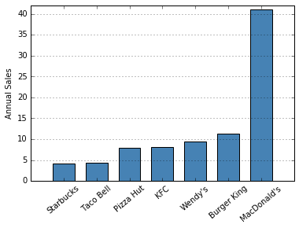

```python
sales = [4.1, 4.3, 8, 8.2, 9.4, 11.3, 41]
width = 1/1.5

figure, axes = plt.subplots()
x = range( len( sales))
axes.bar(x, sales, width, color="steelblue", align="center")
axes.set_xticks([0, 1, 2, 3, 4, 5, 6])
axes.set_xticklabels(["Starbucks", "Taco Bell", "Pizza Hut", "KFC", "Wendy's", "Burger King", "MacDonald's"], rotation=40)
axes.set_ylabel("Annual Sales")
axes.yaxis.grid( b=True, which="major")
axes.set_ylim((0, 42))

plt.show()
```

2.

[figure not shown]

```python
Image( "resources/chart_02.jpg", width=500)
```

**What's wrong:**  
-Uses shape, all with different colors which doesn't add to message  
-Uses pie chart for onion import  
-No similarity between each "graph"  
-Violates Principle of Proximity and muddies the message  
-Random positions for each food, muddies the message

|  | Percentage of Total Consumption Imported from non-American Countries |
| --- | --- |
| Fruits and Nuts | 51% |
| Veggies | 20% |
| Honey | 61% |
| Lamb | 52% |
| Seafood | 88% |

3.

[figure not shown]

```python
Image( "resources/chart_03.jpg", width=500)
```

**What's wrong:**  
-Y axis doesn't start at 0  
-Larger territory labels are vertical  
-Order left to right of territories seems random  
-Bar chart seems like a bad fit for the data

**Fix:** A better fit would be a map of Canada with two different color intensities for a drinking age of 18 and 19. If that isn't available, a simple chart could be sufficient.

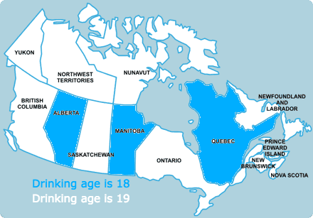

```python
Image("canada.png", width=600)
```

4.

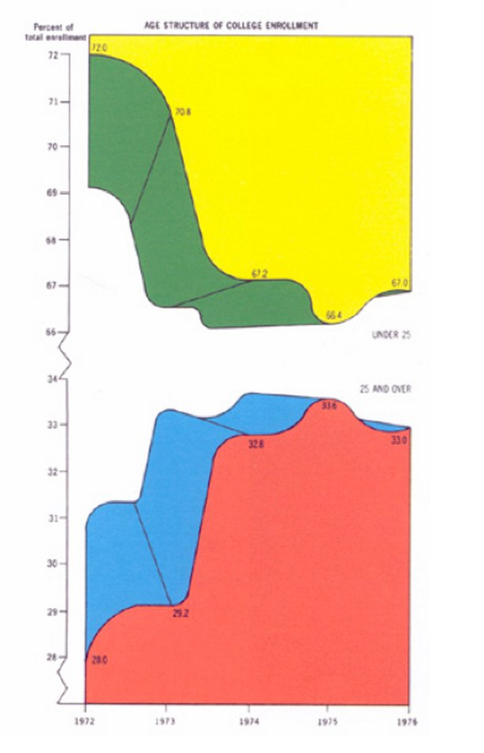

```python
Image( "resources/chart_04.jpg", width=500)
```

Fix: This is clear part/whole relationship that can benefit from being expressed as a bar chart.

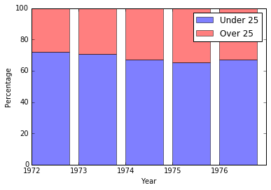

```python
under_25_data = [72, 70.8, 67.2, 65.4, 67]
over_25_data = [100 - percent for percent in under_25_data]
figure, axes = plt.subplots()
axes.bar(range(len(under_25_data)), under_25_data, label="Under 25", alpha=0.5, color='b')
axes.bar(range(len(over_25_data)), over_25_data, bottom=under_25_data, label="Over 25", alpha=0.5, color='r')
plt.sca(axes)
plt.xticks([0, 1, 2, 3, 4], ['1972', '1973', '1974', '1975', '1976'])
axes.set_ylabel("Percentage")
axes.set_xlabel("Year")
plt.legend(loc='best')
plt.show()
```

5.

[figure not shown]

```python
Image( "resources/chart_05.jpg", width=500)
```

**What's wrong:**  
-x-axis spacing is not consistent, jumps from 9 months to 6 to 15.  
-no y-axis labels  
-title is misleading since x-axis spacing is off

**Fix:** simple line chart with updated title, y-axis label and better spacing for x-axis

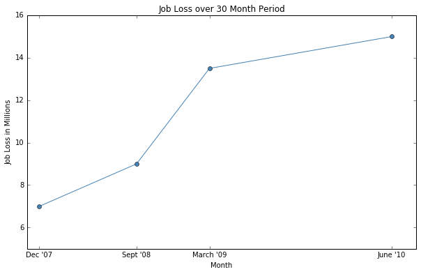

```python
figure = plt.figure(figsize=(10, 6))

xs = [1, 9, 15, 30]
ys = [7, 9, 13.5, 15]

axes = figure.add_subplot(1, 1, 1)
axes.plot(xs, ys, "o-", color="steelblue")
axes.set_xlim((0, 32))
axes.set_ylim((5, 16))
axes.set_ylabel("Job Loss in Millions")
axes.set_xlabel("Month")
axes.set_xticks(xs)
axes.set_xticklabels(["Dec '07", "Sept '08", "March '09", "June '10"])
plt.title("Job Loss over 30 Month Period")
```

6.

[figure not shown]

```python
Image( "resources/chart_06.jpg", width=500)
```

**What's wrong:**  
-Title is misleading since the President has more than one year in office  
-The right most point does not align to the y-axis values at all. This can be particularly misleading as this right most point was probably the unemployment rate at the time this chart was publicly display. Although unemployment is 8.6% at the time, it appears on the same y-axis line as 9.0%.

**Fix:** Add more y-axis tick marks and regenerate line chart with data to remove basis

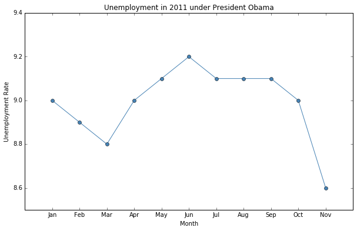

```python
figure = plt.figure(figsize=(10, 6))

xs = [1, 2, 3, 4, 5, 6, 7, 8, 9, 10, 11]
ys = [9.0, 8.9, 8.8, 9.0, 9.1, 9.2, 9.1, 9.1, 9.1, 9.0, 8.6]

axes = figure.add_subplot(1, 1, 1)
axes.plot(xs, ys, "o-", color="steelblue")
axes.set_xlim((0, 12))
axes.set_ylim((8.5, 9.4))
axes.set_ylabel("Unemployment Rate")
axes.set_xlabel("Month")
axes.set_xticks(xs)
axes.set_xticklabels(["Jan", "Feb", "Mar", "Apr", "May", "Jun", "Jul", "Aug", "Sep", "Oct", "Nov"])
plt.title("Unemployment in 2011 under President Obama")
```

## Lab Discussion

In addition to the charts above, discuss what is wrong with the following charts in your lab discussion group and suggest alternatives. You should also consider context.

You should also start being critical of context. For example, look at the US unemployment rate for Chart 6, in context for the preceding years (Fox News can't be faulted for not predicting the future! [US unemployment rate](http://data.bls.gov/timeseries/LNS14000000)). When did Obama take office? In Chart 7, what were apprehensions in previous years?

Do not attempt to provide an answer for all of them. Divide the charts amongst yourselves to provide the initial post and then continue the discussion.

[figure not shown]

```python
Image( "resources/chart_07.jpg", width=500)
```

**What's wrong:**  
-Y-axis doesn't start at 0  
-Title conflicts with x-axis spacing (one is in years and one is in months), is that supposed to mean the apprehensions from Oct to Apr in 2011?  
-Little context is conveyed because only 3 years of data are presented. (courtesy of Christopher from my group discussion)  
-Color saturation is strange and doesn't improve the clarity of the message (courtesy of Christopher from my group discussion)

**Fix:** bar chart with y-axis starting at 0 and properly labeled x-axis (courtesy of Christopher from my group discussion)

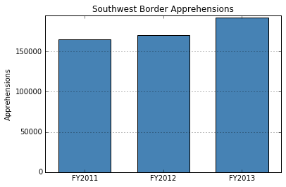

```python
swb_data = [165244,170223,192298]

xs = [1, 2, 3]

width = 1/1.5

figure, axes = plt.subplots()

axes.bar(xs, swb_data, width, color="steelblue", align="center")
axes.set_xticks(xs)
axes.set_xticklabels(["FY2011", "FY2012", "FY2013"])
axes.yaxis.grid( b=True, which="major")
axes.set_ylim((0, 195000))
plt.title("Southwest Border Apprehensions")
axes.set_ylabel("Apprehensions")
plt.show()
```

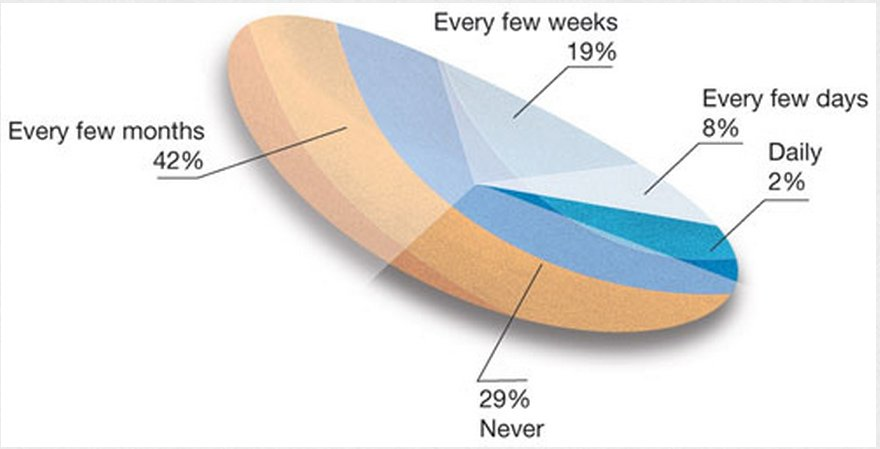

```python
Image( "resources/chart_08.jpg", width=500)
```

**What's wrong:**  
-Presented as pie chart  
-Slanted orientation of chart makes it difficult to digest message (courtesy of Christopher)  
-Unhelpful use of color and shading (courtesy of Christopher)

**Fix:** Histogram with y-axis being percentage and x-axis being time frequency categories

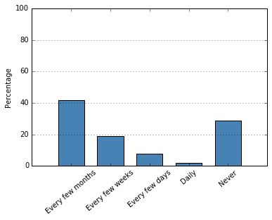

```python
chart_8_data = [42, 19, 8, 2, 29]
chart_8_x_labels = ['Every few months', 'Every few weeks', 'Every few days', 'Daily', 'Never']
width = 1/1.5

figure, axes = plt.subplots()

axes.bar([0,1,2,3,4], chart_8_data, width, color="steelblue", align="center")
axes.set_xticks([0, 1, 2, 3, 4])
axes.set_xticklabels(chart_8_x_labels, rotation=40)
axes.yaxis.grid( b=True, which="major")
axes.set_ylim((0, 100))
axes.set_ylabel("Percentage")

plt.show()
```

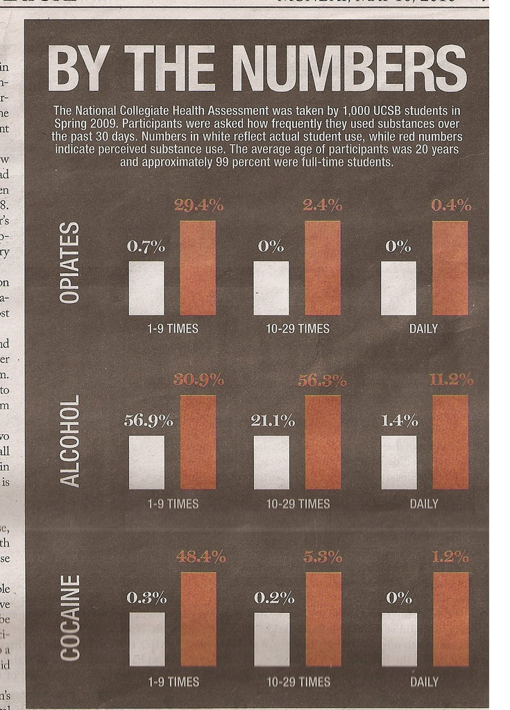

```python
Image( "resources/chart_09.jpg", width=500)
```

**What's wrong:**  
-Red bars and numbers are meant to describe 'perceived use' of substances, as opposed to white describing actual. This is somewhat counterintuitive as we usually perceive red to be more severe than white, and one could argue the actual use of these substances is more concerning than the perceived. (courtesy of Christopher from group discussion)  
-heights of bar aren't proportional to values  
-Not color blind safe (courtesy of Christopher)

**Fix:** Break each drug out to separate graphs

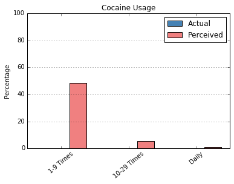

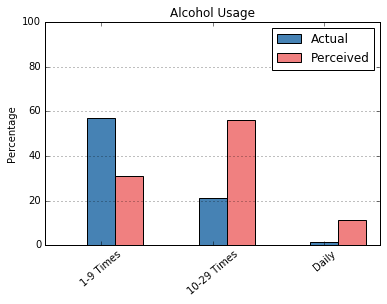

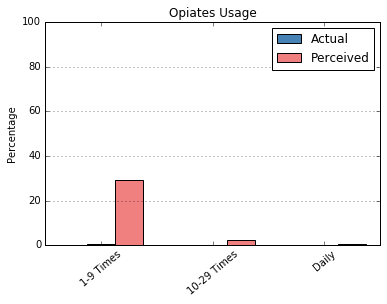

```python
cocaine_data_actual = [0.3, 0.2, 0.0]
cocaine_data_perceived = [48.4, 5.3, 1.2]
ind = np.arange(3)

x_labels = ['1-9 Times', '10-29 Times', 'Daily']
width = 0.25

figure, axes = plt.subplots()

rect1 = axes.bar(ind, cocaine_data_actual, width, color="steelblue", align="center")
rect2 = axes.bar(ind + width, cocaine_data_perceived, width, color="lightcoral", align="center")
axes.set_xticks([0, 1,2])
axes.set_xticklabels(x_labels, rotation=40)
axes.yaxis.grid( b=True, which="major")
axes.set_ylim((0, 100))
axes.set_ylabel("Percentage")
plt.title("Cocaine Usage")
axes.legend((rect1[0], rect2[0]), ('Actual', 'Perceived'))
plt.show()

a_data_actual = [56.9,21.1,1.4]
a_data_perceived = [30.9,56.3,11.2]
figure, axes = plt.subplots()

rect1=axes.bar(ind, a_data_actual, width, color="steelblue", align="center")
rect2=axes.bar(ind + width, a_data_perceived, width, color="lightcoral", align="center")
axes.set_xticks([0, 1, 2])
axes.set_xticklabels(x_labels, rotation=40)
axes.yaxis.grid( b=True, which="major")
axes.set_ylim((0, 100))
axes.legend((rect1[0], rect2[0]), ('Actual', 'Perceived'))
axes.set_ylabel("Percentage")
plt.title("Alcohol Usage")
plt.show()

h_data_actual = [0.7, 0,0]
h_data_perceived = [29.4,2.4,0.4]
figure, axes = plt.subplots()

rect1=axes.bar(ind, h_data_actual, width, color="steelblue", align="center")
rect2=axes.bar(ind + width, h_data_perceived, width, color="lightcoral", align="center")
axes.set_xticks([0, 1, 2])
axes.set_xticklabels(x_labels, rotation=40)
axes.yaxis.grid( b=True, which="major")
axes.set_ylim((0, 100))
axes.set_ylabel("Percentage")
axes.legend((rect1[0], rect2[0]), ('Actual', 'Perceived'))
plt.title("Opiates Usage")
plt.show()
```

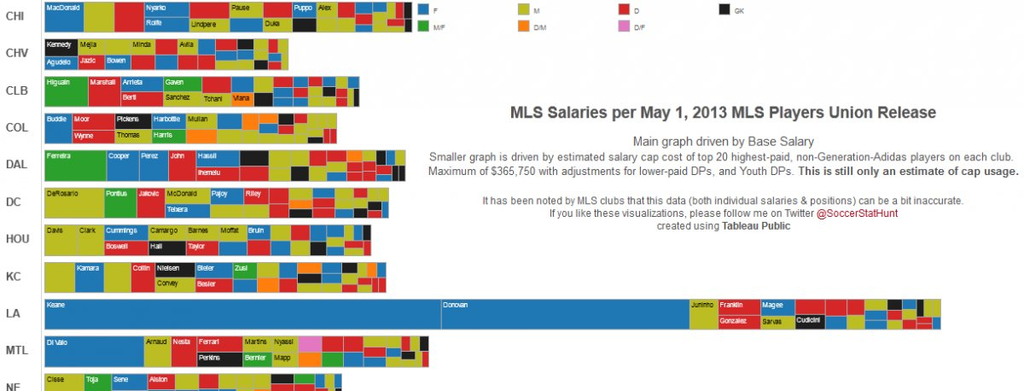

```python
Image( "resources/chart_10.jpg", width=750)
```

**What's wrong:**  
-Not color blind safe  
-Too many messages in one chart (Which team has the highest wage rates? Which position is paid the most? Which individual player is paid the most?) (courtesy of Katrina)  
-No x-axis scale so we don't know the differences between teams (courtesy of Christopher)  
-Within a team, differences are expressed in shapes (both width and height) so it is very difficult to quantify them

**Fix:** Rather than 3 or 4 messages for a single chart, I'm deciding to chart the total wage spend of each team via a bar chart. Similar bar charts could be developed for the other messages in the original chart.

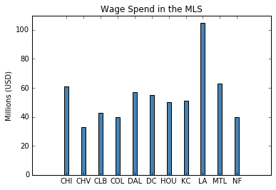

```python
mls_spend = [61,33,43, 40, 57, 55, 50, 51, 105, 63, 40]
x_labels = ['CHI', 'CHV', 'CLB', 'COL', 'DAL', 'DC', 'HOU', 'KC', 'LA', 'MTL', 'NF']
figure, axes = plt.subplots()

rect1=axes.bar(range(len(x_labels)), mls_spend, width, color="steelblue", align="center")
axes.set_xticks(range(len(x_labels)))
axes.set_xticklabels(x_labels)
axes.set_ylim((0, 110))
axes.set_ylabel("Millions (USD)")
plt.title("Wage Spend in the MLS")

plt.show()
```

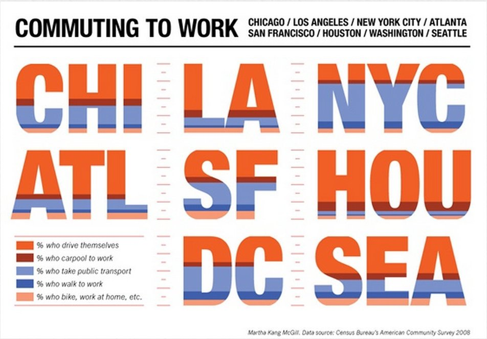

```python
Image( "resources/chart_11.jpg", width=500)
```

**What's wrong:**  
-Using different shapes (like the logo chart above) makes it difficult to compare cities and doesn't allow for a consistent bar width  
-No y-axis. This isn't necessarily a problem if the point of the chart is to draw attention to the proportion in indivdiual cities. However, since 8 cities are listed, I'm assuming the author wants the reader to compare proportions between cities

**Fix:** Since comparsion is the main focus, I think a table will help the reader the most.

| State | Drive Themselves | Carpool to Work | Public Transport | Walk | Bike/Work from Home |
| --- | --- | --- | --- | --- | --- |
| Chicago | 50% | 10% | 25% | 5% | 10% |
| Atlanta | 75% | 5% | 10% | 2% | 8% |
| LA | 75% | 10% | 10% | 1% | 4% |
| San Fran | 25% | 10% | 35% | 10% | 20% |
| D.C. | 25% | 15% | 35% | 10% | 15% |
| NYC | 15% | 5% | 60% | 10% | 10% |
| Houston | 80% | 10% | 4% | 1% | 5% |
| Seattle | 50% | 15% | 20% | 5% | 10% |

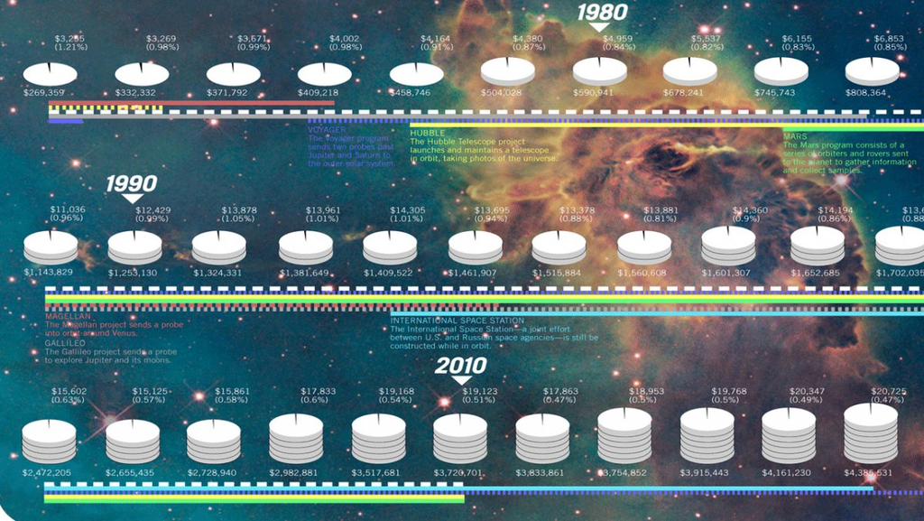

```python
Image( "resources/chart_12.jpg", width=750)
```

**What's wrong:**  
-Pie charts! And small ones at that, to the point where I can't see the difference in each one.  
-Charts are so spread out that it makes them feel disjoint but they are actual all one big chart -Multiple messages are floating around. How much of NASA's budget accounts for the total nation budget? How much does the total nation budget increase each year? -Percentage and total nation budget numbers are redundant -Although pretty, the background image is distracting

**Fix:** Consolidate all data into 1 line chart that graphs the percentage of NASA budget to total nation budget over time

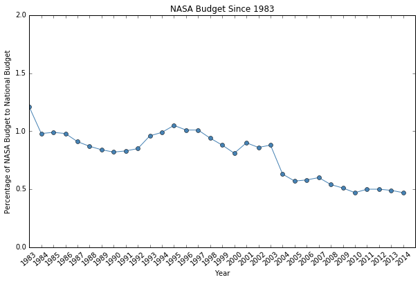

```python
nasa_data = [1.21, 0.98, 0.99, 0.98, 0.91, 0.87, 0.84, 0.82, 0.83, 0.85, 0.96, 0.99, 1.05, 1.01, 1.01, 0.94, 0.88, 0.81, 0.9, 0.86, 0.88, 0.63, 0.57, 0.58, 0.6, 0.54, 0.51, 0.47, 0.5, 0.5, 0.49, 0.47]
figure = plt.figure(figsize=(10, 6))
xs = range(2015-1983)

axes = figure.add_subplot(1, 1, 1)
axes.plot(xs, nasa_data, "o-", color="steelblue")
axes.set_xlim((0, 32))
axes.set_ylim((0, 2))
axes.set_ylabel("Percentage of NASA Budget to National Budget")
axes.set_xlabel("Year")
axes.set_xticks(xs)
axes.set_xticklabels(range(1983, 2015), rotation=40)
plt.title("NASA Budget Since 1983")
```

[figure not shown]

```python
Image( "resources/chart_13.jpg", width=500)
```

**What's wrong:**  
-Uses pie charts  
-Each chart is a separate message  
-Having 6 charts so close together feels like information overload  
-The time spans are oddly divided, need to convert them to the same time period

**Fix:** Break each of the 6 charts out to a bar chart where the x-axis are the four time categories and the y-axis is the percentage. A fix is shown for the 'Machine Learning' chart.

[figure not shown]

```python
ml_data = [34, 29, 24, 10]
width = 1/1.5

figure, axes = plt.subplots()
x = range( len( ml_data))
axes.bar(x, ml_data, width, color="steelblue", align="center")
axes.set_xticks([0, 1, 2, 3])
axes.set_xticklabels(["Less than 1 hour a week", "1 - 4 hrs/wk", "5 - 15 hrs/wk", "20 or more hrs/wk"], rotation=40)
axes.set_ylabel("Percentage")
axes.yaxis.grid( b=True, which="major")
axes.set_ylim((0, 42))

plt.show()
```

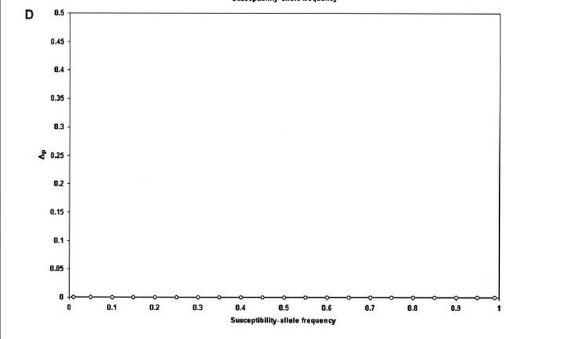

```python
Image( "resources/chart_14.jpg", width=500)
```

**What's wrong:**  
-Y-axis scale dwarfs the data points  
-If data points are all 0, no chart is needed. Simply summarize that variable x is unaffected by variable y

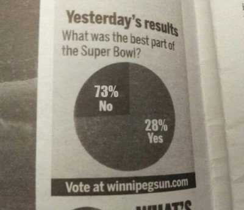

```python
Image( "resources/chart_15.jpg", width=500)
```

**What's wrong:**  
-Survey question doesn't make sense (courtesy of Cuong)  
-73% slice is displayed as smaller than 28% slice (courtesy of Cuong)  
-Rounding error when adding up slices (courtesy of Cuong)  
-Uses pie chart

**Fix:**Simple table

[output not shown]

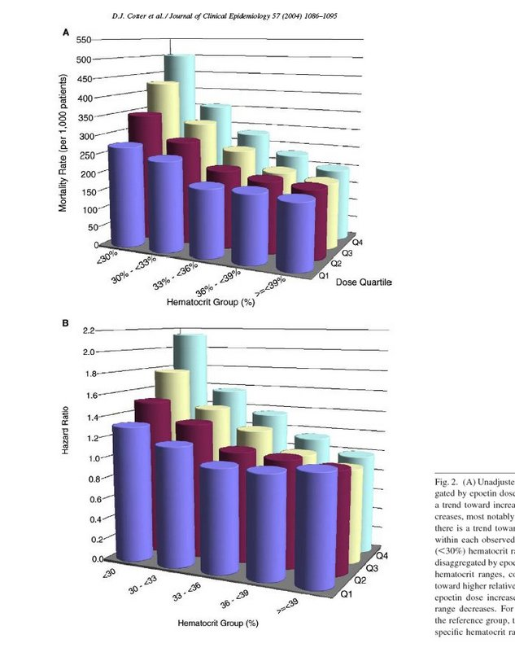

```python
Image( "resources/chart_16.jpg", width=500)
```

**What's wrong:**

-Appears to break the law of small multiples, since each dose quantile could probably be broken out to its our chart. Would this ruin its original message?  
-3-d scale makes determining actual bar values near impossible  
-New colors may better emphasis grouping  
-x-axis groups aren't of each width